# Proyecto final - Gastón Gratani

### Armo dataset solamente con embriones que fueron transferidos

Embriones transferidos

|  | Protocolo | Fecha | PacienteEdad | OvulosDonante | SemenDonante | OvulosVitrificados | EDV | Embrion | Dia | FivIcsi | ... | Aborto | Nº sacos abortados | Nacimientos | SDG | Nacidos Vivos | Nº Nacidos Vivos | Nacidos Muertos | Nº Nacidos Muertos | Medio de cultivo | Conclusiones |
| --- | --- | --- | --- | --- | --- | --- | --- | --- | --- | --- | --- | --- | --- | --- | --- | --- | --- | --- | --- | --- | --- |
| 6 | 05-022-FI | 2005-11-24 | NaN | NO | SI | NO | NaN | 15 | 2 | ICSI | ... | NO | NaN | NO | NaN | NO | NaN | NO | NaN | NaN | NaN |
| 14 | 05-022-FI | 2005-11-24 | NaN | NO | SI | NO | NaN | 11 | 2 | ICSI | ... | NO | NaN | NO | NaN | NO | NaN | NO | NaN | NaN | NaN |
| 19 | 06-002-FI | 2006-03-02 | 27.0 | NO | NO | NO | NaN | 2 | 2 | ICSI | ... | NO | NaN | NO | NaN | NO | NaN | NO | NaN | NaN | NaN |
| 20 | 06-002-FI | 2006-03-02 | 27.0 | NO | NO | NO | NaN | 3 | 2 | ICSI | ... | NO | NaN | NO | NaN | NO | NaN | NO | NaN | NaN | NaN |
| 30 | 06-022-FI | 2006-06-07 | NaN | NO | NO | NO | NaN | 4 | 2 | ICSI | ... | NO | NaN | SI | NaN | SI | 1.0 | NO | NaN | NaN | NaN |

5 rows × 65 columns

```
Hay 4185 embriones transferidos
```

Pacientes a los que se les transfirió

```
En total hay 4185 embriones transferidos
La cantidad de pacientes a los que se les transfirio al menos un embrion es: 2508
```

### De los que fueron tansferidos, cuantos nacieron?

```
De los pacientes a los que se les transfirio, 502 tuvieron nacimientos
```

### A cuantos pacientes se les transfirió mas de un embrion

¿Hay relación entre cantidad de embriones transfridos y probabilidad de tener nacimiento? Es decir, ¿Si se transfieren mas embriones, es mas probable que tenga exito el tratamiento?

| Cantidad de embriones transferidos por paciente | Cantidad transferidos | Cantidad nacidos | Relación |
| --- | --- | --- | --- |
| 1 | 948 | 146 | 0.15 |
| 2 | 1443 | 330 | 0.23 |
| 3 | 117 | 26 | 0.22 |

### Cuento cuantos registros hay de cada medio de cultivo

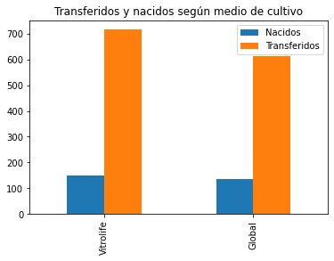

[output not shown]

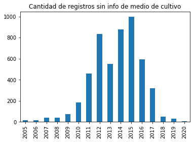

#### Obtengo cantidades

```
Cantidad de nacidos con Global: 134
Cantidad de nacidos con Vitrolife: 148
Sin informacion de medio de cultivo: 220
```

```
Cantidad total con Global: 4489
Cantidad total con Vitrolife: 4421
Sin informacion de medio de cultivo: 5087
```

```
Cantidad de transferidos con Global: 954
Cantidad de transferidos con Vitrolife: 1083
Sin información de medio de cultivo: 2148
```

## Calculo relaciones totales

```
La cantidad total de pacientes es de 3385
```

```
El porcentaje de pacientes con bebes nacidos es de: 14.83
El porcentaje de pacientes a los que se transfirio al menos 1 embrion es de: 74.09
```

No tiene sentido comparar global y vitrolife porque hay mucha informacion faltante de medio de cultivo

### De los transferidos, comparo medio de cultivo de los no nacidos

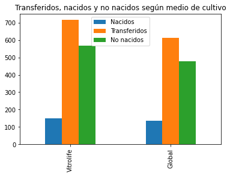

### Cuantos no tienen info de nacimiento?

Puede pasar que no haya información por perdida de contacto con paciente

[output not shown]

### Análisis de embarazos

Hay algun caso de nacimiento que diga embarazo clinico es NO? No debería

|  | Protocolo | Fecha | PacienteEdad | OvulosDonante | SemenDonante | OvulosVitrificados | EDV | Embrion | Dia | FivIcsi | ... | Aborto | Nº sacos abortados | Nacimientos | SDG | Nacidos Vivos | Nº Nacidos Vivos | Nacidos Muertos | Nº Nacidos Muertos | Medio de cultivo | Conclusiones |
| --- | --- | --- | --- | --- | --- | --- | --- | --- | --- | --- | --- | --- | --- | --- | --- | --- | --- | --- | --- | --- | --- |
| 5383 | 16-431-FI | 2016-12-26 | 28.0 | NO | NO | NO | NO | 2 | 2 | ICSI | ... | NO | NaN | SI | 34.0 | SI | 2.0 | NO | NaN | NaN | Parto (&gt;=21 S) |
| 9790 | 19-061-FI | 2019-02-19 | 37.0 | NO | NO | NO | NO | 6 | 2 | ICSI | ... | NO | NaN | SI | NaN | NO | NaN | NO | NaN | Global | Embarazo Bioquímico (&lt;6 S) |

2 rows × 65 columns

Hay algun caso de nacimiento que diga embarazo bioquimico es SI? debería(??)

|  | Protocolo | Fecha | PacienteEdad | OvulosDonante | SemenDonante | OvulosVitrificados | EDV | Embrion | Dia | FivIcsi | ... | Aborto | Nº sacos abortados | Nacimientos | SDG | Nacidos Vivos | Nº Nacidos Vivos | Nacidos Muertos | Nº Nacidos Muertos | Medio de cultivo | Conclusiones |
| --- | --- | --- | --- | --- | --- | --- | --- | --- | --- | --- | --- | --- | --- | --- | --- | --- | --- | --- | --- | --- | --- |
| 30 | 06-022-FI | 2006-06-07 | NaN | NO | NO | NO | NaN | 4 | 2 | ICSI | ... | NO | NaN | SI | NaN | SI | 1.0 | NO | NaN | NaN | NaN |
| 33 | 06-032-FI | 2006-09-05 | 37.0 | NO | NO | NO | NaN | 4 | 2 | ICSI | ... | NO | NaN | SI | NaN | SI | 1.0 | NO | NaN | NaN | NaN |
| 71 | 07-046-FI | 2007-12-16 | NaN | NO | NO | NO | NaN | 5 | 2 | ICSI | ... | NO | NaN | SI | NaN | SI | 1.0 | NO | NaN | NaN | NaN |
| 113 | 09-002-FI | 2009-02-08 | 32.0 | NO | NO | NO | NaN | 2 | 2 | ICSI | ... | NO | NaN | SI | NaN | SI | 3.0 | NO | NaN | NaN | NaN |
| 230 | 10-047-FI | 2010-06-08 | NaN | SI | NO | NO | NaN | 3 | 2 | ICSI | ... | NO | NaN | SI | NaN | SI | 2.0 | NO | NaN | NaN | NaN |
| ... | ... | ... | ... | ... | ... | ... | ... | ... | ... | ... | ... | ... | ... | ... | ... | ... | ... | ... | ... | ... | ... |
| 13931 | 20-470-FI | 2020-12-18 | 39.0 | SI | SI | SI | SI | 11 | 2 | ICSI | ... | NO | NaN | SI | 40.0 | SI | 1.0 | NO | NaN | Vitrolife | Parto (&gt;=21 S) |
| 13933 | 20-471-FI | 2020-12-20 | 34.0 | NO | NO | NO | NO | 1 | 2 | ICSI | ... | NO | NaN | SI | 37.0 | SI | 1.0 | NO | NaN | Vitrolife | Parto (&gt;=21 S) |
| 13942 | 20-474-FI | 2020-12-24 | 35.0 | SI | NO | NO | NO | 4 | 2 | ICSI | ... | NO | NaN | SI | 37.0 | SI | 1.0 | NO | NaN | Vitrolife | Parto (&gt;=21 S) |
| 13951 | 20-476-FI | 2020-12-24 | 39.0 | SI | NO | NO | NO | 1 | 2 | ICSI | ... | NO | NaN | SI | 35.0 | SI | 1.0 | NO | NaN | Vitrolife | Parto (&gt;=21 S) |
| 13994 | 20-484-FI | 2020-12-31 | 48.0 | SI | NO | NO | NO | 3 | 2 | ICSI | ... | NO | NaN | SI | 38.0 | SI | 1.0 | NO | NaN | Vitrolife | Parto (&gt;=21 S) |

501 rows × 65 columns

### Separo por ID, cuantos pacientes tuvieron al menos 1 nacimiento

Ya se calculo antes, lo hago de otra manera para verificar

```
De 3385 pacientes, solo 504 tuvieron nacimientos
Porcentaje: 14.889217134416544 %
```

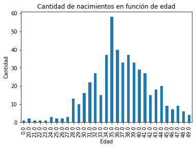

Error en base, se detecta que hay paciente con edad incorrecta

|  | Protocolo | Fecha | PacienteEdad | OvulosDonante | SemenDonante | OvulosVitrificados | EDV | Embrion | Dia | FivIcsi | ... | Nº sacos abortados | Nacimientos | SDG | Nacidos Vivos | Nº Nacidos Vivos | Nacidos Muertos | Nº Nacidos Muertos | Medio de cultivo | Conclusiones | Fecha_year |
| --- | --- | --- | --- | --- | --- | --- | --- | --- | --- | --- | --- | --- | --- | --- | --- | --- | --- | --- | --- | --- | --- |
| 495 | 11-037-FI | 2011-06-08 | 0.0 | NO | NO | NO | NaN | 1 | 2 | ICSI | ... | NaN | SI | NaN | SI | 2.0 | NO | NaN | NaN | NaN | 2011 |

1 rows × 66 columns

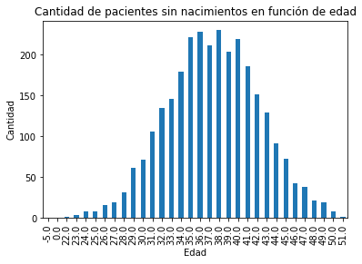

#### Hay casos de embarazo clinico pero no nacidos?

```
Hay 105 casos de embarazos clinicos pero sin nacimientos
```

### Armo dataset de transferidos y día en que fue transferido

|  | Protocolo | Fecha | PacienteEdad | OvulosDonante | SemenDonante | OvulosVitrificados | EDV | Embrion | Dia | FivIcsi | ... | Nº sacos abortados | Nacimientos | SDG | Nacidos Vivos | Nº Nacidos Vivos | Nacidos Muertos | Nº Nacidos Muertos | Medio de cultivo | Conclusiones | Fecha_year |
| --- | --- | --- | --- | --- | --- | --- | --- | --- | --- | --- | --- | --- | --- | --- | --- | --- | --- | --- | --- | --- | --- |
| 6 | 05-022-FI | 2005-11-24 | NaN | NO | SI | NO | NaN | 15 | 2 | ICSI | ... | NaN | NO | NaN | NO | NaN | NO | NaN | NaN | NaN | 2005 |
| 14 | 05-022-FI | 2005-11-24 | NaN | NO | SI | NO | NaN | 11 | 2 | ICSI | ... | NaN | NO | NaN | NO | NaN | NO | NaN | NaN | NaN | 2005 |
| 19 | 06-002-FI | 2006-03-02 | 27.0 | NO | NO | NO | NaN | 2 | 2 | ICSI | ... | NaN | NO | NaN | NO | NaN | NO | NaN | NaN | NaN | 2006 |
| 20 | 06-002-FI | 2006-03-02 | 27.0 | NO | NO | NO | NaN | 3 | 2 | ICSI | ... | NaN | NO | NaN | NO | NaN | NO | NaN | NaN | NaN | 2006 |
| 30 | 06-022-FI | 2006-06-07 | NaN | NO | NO | NO | NaN | 4 | 2 | ICSI | ... | NaN | SI | NaN | SI | 1.0 | NO | NaN | NaN | NaN | 2006 |

5 rows × 66 columns

```
Hay 4192 embriones transferidos
```

Me da algunos casos mas que antes porque aca estoy contando transferidos en el día 6 tambien

Tabla comparativa de cantidades de pacientes que tuvieron transferencias. Indica cuantos tuvieron nacimientos segun el día de transferencia

|  | Transferencia día 2 | Transferencia día 3 | Transferencia día 5 |
| --- | --- | --- | --- |
| NO | 725 | 1023 | 230 |
| SI | 113 | 291 | 99 |
| NaN | 4 | 20 | 4 |

## Busco relacion entre nacimientos y MCI

Agrupo por id de paciente, nacimientos y MCI. Si bien la cantidad de pacientes a los que se les transfirio en el quinto día es de:

```
333
```

, a algunos pacientes se les transfirio mas de un embrion. Si hubo embarazo no se sabe de que embrion proviene. Por eso la cantidad total de embriones transferidos al quinto día es de:

```
375.0
```

| Nacimientos MCI | NO | SI |
| --- | --- | --- |
|  | 31.0 | 10.0 |
| A | 48.0 | 22.0 |
| B | 162.0 | 79.0 |
| C | 20.0 | 3.0 |

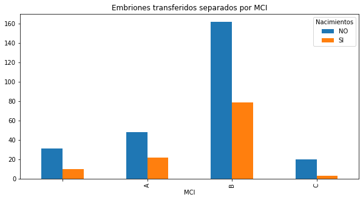

El gráfico representa a todos los embriones transferidos en el quinto día y si pacientes tuvieron naciemientos según MCI

| Nacimientos | Relación A | Relación B | Relación C |
| --- | --- | --- | --- |
| SI | 0.314286 | 0.327801 | 0.130435 |

Era de esperar que los MCI = C tengan una relación de éxito menor, pero ¿Por que se transfirieron embriones con MCI = C ?

```
23 embriones transferidos con MCI = C pertenecen a 18 pacientes diferentes
```

Hago merge para encontrar todos los registros de esos pacientes, a ver que pasó con los demás embriones de esos pacientes

Se observa que todos los pacientes tienen en base mas de 1 embrión

```
Cantidad total de embriones entre esos pacientes 101
Cantidad total de embriones transferidos de esos pacientes 34
Cantidad de embriones de esos pacientes transferidos con MCI = C 23
```

Se observa que para todos los pacientes se transfirieron el quinto día. Aunque en algunos casos no hay información de MCI

| Protocolo | MCI | Nacimientos Trafectodermo | NO | SI |
| --- | --- | --- | --- | --- |
| 14-125-FI | C | A | 2.0 | 0.0 |
| 14-170-FI | B | A | 1.0 | 0.0 |
|  | C | A | 1.0 | 0.0 |
| 14-204-FI | C | C | 2.0 | 0.0 |
| 14-207-FI | B | C | 1.0 | 0.0 |
|  | C | C | 1.0 | 0.0 |
| 15-029-FI | A | B | 1.0 | 0.0 |
|  | C | C | 1.0 | 0.0 |
| 15-030-FI | B | C | 1.0 | 0.0 |
|  | C | A | 1.0 | 0.0 |
| 15-097-FI | C | C | 2.0 | 0.0 |
| 15-233-FI |  |  | 1.0 | 0.0 |
|  | C | C | 1.0 | 0.0 |
| 16-213-FI |  |  | 1.0 | 0.0 |
|  | C | B | 1.0 | 0.0 |
| 16-432-FI |  |  | 1.0 | 0.0 |
|  | C | B | 1.0 | 0.0 |
| 17-113-FI | C | B | 2.0 | 0.0 |
| 17-221-FI | C | B | 1.0 | 0.0 |
| 17-307-FI | C | A | 0.0 | 1.0 |
|  |  | B | 0.0 | 1.0 |
| 17-315-FI |  |  | 1.0 | 0.0 |
|  | C | C | 1.0 | 0.0 |
| 18-020-FI |  |  | 0.0 | 1.0 |
|  | C | A | 0.0 | 1.0 |
| 18-021-FI |  |  | 1.0 | 0.0 |
|  | C | A | 1.0 | 0.0 |
| 19-011-FI | C | C | 1.0 | 0.0 |
| 20-078-FI |  |  | 1.0 | 0.0 |
|  | C | B | 1.0 | 0.0 |

### Busco relacion entre nacimientos y celulas del día 3 para los que llegaron a blastocistos

| Nacimientos Celulas | NO | SI |
| --- | --- | --- |
| 0 | 0.0 | 1.0 |
| 3 | 1.0 | 0.0 |
| 4 | 1.0 | 0.0 |
| 5 | 1.0 | 2.0 |
| 6 | 13.0 | 2.0 |
| 7 | 33.0 | 12.0 |
| 8 | 145.0 | 63.0 |
| 9 | 35.0 | 14.0 |
| 10 | 18.0 | 9.0 |
| 11 | 8.0 | 3.0 |
| 12 | 3.0 | 4.0 |
| 13 | 0.0 | 2.0 |
| 14 | 3.0 | 1.0 |
| Compactado | 0.0 | 1.0 |

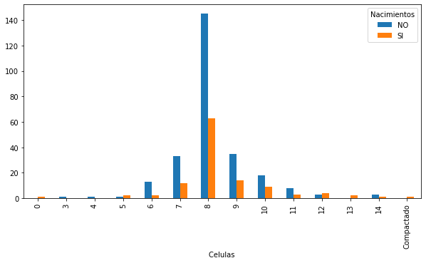

Estos son los mismos embriones que en el caso anterior, me quería fijar si habia alguna tendencia en cuanto a la cantidad de celulas al día 3

### Busco relacion entre MCI, trafectodermo y grado de expansión para nacimientos

Igual que caso anterior pero no analizo solamente MCI, agreo Trafectodermo y Grado de expanción

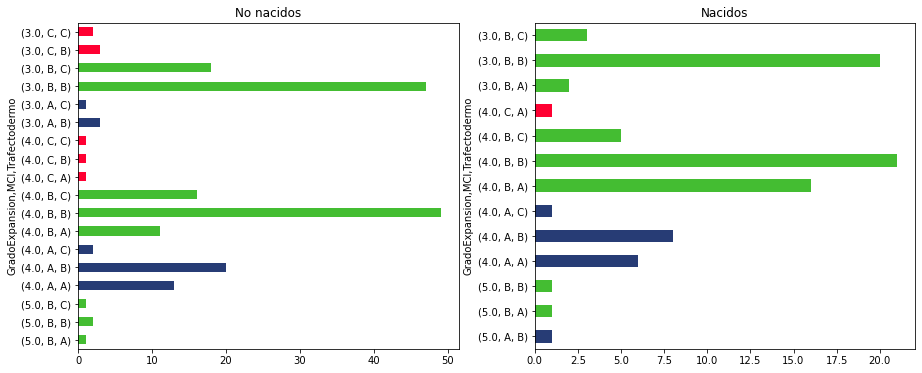

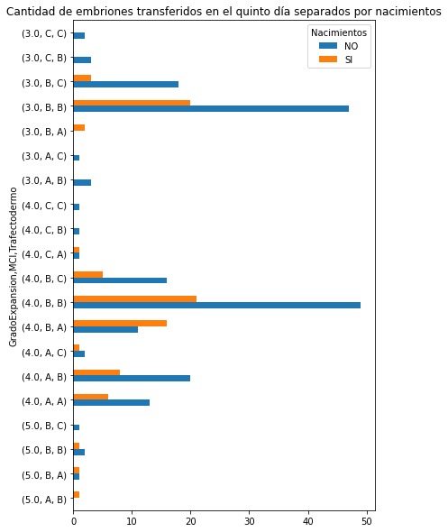

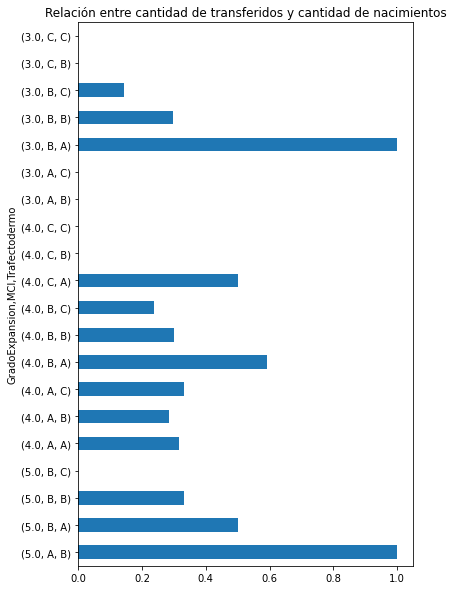

### Busco relacion entre Transferencia y MCI para los que llegaron a blastocistos

Si no llega a blasto, no hay info de mci, traf, etc

| Protocolo | MCI Destino_M |  | A | B | C | D |
| --- | --- | --- | --- | --- | --- | --- |
| 12-005-FI | NO VIABLE | 2.0 | NaN | NaN | NaN | NaN |
| 12-037-FI | NO VIABLE | NaN | NaN | NaN | 1.0 | NaN |
| 12-095-FI | NO VIABLE | NaN | NaN | 1.0 | NaN | NaN |
| 12-098-FI | TRANSFERIDO O CONGELADO | NaN | NaN | 1.0 | NaN | NaN |
| 12-107-FI | NO VIABLE | NaN | NaN | NaN | 1.0 | NaN |
| ... | ... | ... | ... | ... | ... | ... |
| 20-480-FI | TRANSFERIDO O CONGELADO | NaN | NaN | 4.0 | NaN | NaN |
| 20-482-FI | NO VIABLE | NaN | NaN | NaN | 1.0 | NaN |
|  | TRANSFERIDO O CONGELADO | NaN | NaN | 1.0 | NaN | NaN |
| 20-483-FI | TRANSFERIDO O CONGELADO | NaN | NaN | 1.0 | NaN | NaN |
| 20-484-FI | TRANSFERIDO O CONGELADO | NaN | 2.0 | NaN | NaN | NaN |

1395 rows × 5 columns

| Destino_M MCI | NO VIABLE | TRANSFERIDO O CONGELADO |
| --- | --- | --- |
|  | 199.0 | 41.0 |
| A | 8.0 | 233.0 |
| B | 32.0 | 1160.0 |
| C | 602.0 | 32.0 |
| D | 37.0 | 0.0 |

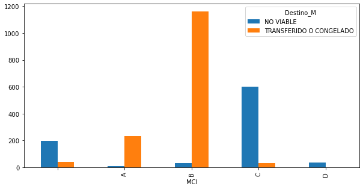